# Principal Component Analysis

## 3. PCA on IRE genes

- We will now restrict genes to ones containing predicted IREs only.
- Previously, we used the **SIREs** webserver to predict IRE-containing genes based on all zebrafish transcript fasta sequences in the GRCz11 reference.
- Here we will import in a list of the genes we predicted to contain IREs.

```r
ireGenes <- readRDS(here("R", "GSEA", "data", "ireGenes.rds"))
ireGenes %>% str
```

```
List of 4
 $ ire3_all: chr [1:1207] "ENSDARG00000102878" "ENSDARG00000070477" "ENSDARG00000006038" "ENSDARG00000063481" ...
 $ ire5_all: chr [1:393] "ENSDARG00000045911" "ENSDARG00000017386" "ENSDARG00000045886" "ENSDARG00000015921" ...
 $ ire3_hq : chr [1:106] "ENSDARG00000074223" "ENSDARG00000024874" "ENSDARG00000110878" "ENSDARG00000089296" ...
 $ ire5_hq : chr [1:49] "ENSDARG00000045911" "ENSDARG00000101351" "ENSDARG00000100006" "ENSDARG00000015551" ...
```

### 3.1. Q96K97 data

- PCA on Q96K97 data, restricted to **3’ IRE genes** indicates good separation between sample groups based on genotype, age, and oxygen level.

```r
q96_expressedIREs <- q96_dge %>% cpm(log=TRUE) %>%
  as.data.frame %>%
  rownames_to_column("ensembl_gene_id") %>%
  dplyr::filter(ensembl_gene_id %in% ireGenes$ire3_all) %>%
  column_to_rownames("ensembl_gene_id") %>%
  as.matrix
pca_q96_ires <- q96_expressedIREs %>% t %>% prcomp
pca_q96_ires_plot <- pca_q96_ires$x %>% magrittr::extract(, c("PC1", "PC2")) %>%
  as.data.frame %>%
  rownames_to_column("samples") %>%
  left_join((q96_dge$samples %>% rownames_to_column("samples")), by="samples") %>%
  ggplot(aes(x=PC1, y = PC2, colour = Hypoxia, shape = paste0(Genotype, "_", Age))) +
  geom_point(alpha = 0.7,size=3) +
  scale_shape_manual(values = c(0,1,15,16),
                     labels = c("Q96K97/+, 24 months", "Q96K97/+, 6 months", "+/+, 24 months", "+/+, 6 months")) +
  theme(aspect.ratio = 1) +
  scale_colour_manual(values = c("cornflowerblue","red"), labels = c("Normoxia","Hypoxia")) +
    labs(x = "Principal Component 1 (26.1%)", y = "Principal Component 2 (8.4%)",
         colour = "Oxygen Level", shape = "Genotype and Age")
summary(pca_q96_ires)
```

```
Importance of components:
                         PC1     PC2     PC3     PC4    PC5     PC6     PC7    PC8     PC9    PC10    PC11    PC12
Standard deviation     5.337 3.03214 2.76967 2.58253 2.4141 2.15325 2.05026 1.8599 1.79566 1.71696 1.69599 1.59274
Proportion of Variance 0.261 0.08424 0.07029 0.06111 0.0534 0.04248 0.03852 0.0317 0.02955 0.02701 0.02636 0.02325
Cumulative Proportion  0.261 0.34525 0.41555 0.47666 0.5301 0.57255 0.61106 0.6428 0.67231 0.69932 0.72568 0.74892
                          PC13    PC14    PC15    PC16    PC17    PC18    PC19    PC20    PC21    PC22    PC23    PC24
Standard deviation     1.53867 1.51122 1.48325 1.42326 1.39677 1.38833 1.30092 1.20328 1.17753 1.15900 1.13352 1.06331
Proportion of Variance 0.02169 0.02093 0.02016 0.01856 0.01788 0.01766 0.01551 0.01327 0.01271 0.01231 0.01177 0.01036
Cumulative Proportion  0.77062 0.79154 0.81170 0.83026 0.84814 0.86580 0.88131 0.89458 0.90728 0.91959 0.93136 0.94172
                          PC25    PC26    PC27    PC28    PC29    PC30    PC31      PC32
Standard deviation     1.05129 1.01952 0.98848 0.93849 0.91401 0.88721 0.85725 8.403e-15
Proportion of Variance 0.01013 0.00952 0.00895 0.00807 0.00765 0.00721 0.00673 0.000e+00
Cumulative Proportion  0.95185 0.96137 0.97033 0.97840 0.98605 0.99327 1.00000 1.000e+00
```

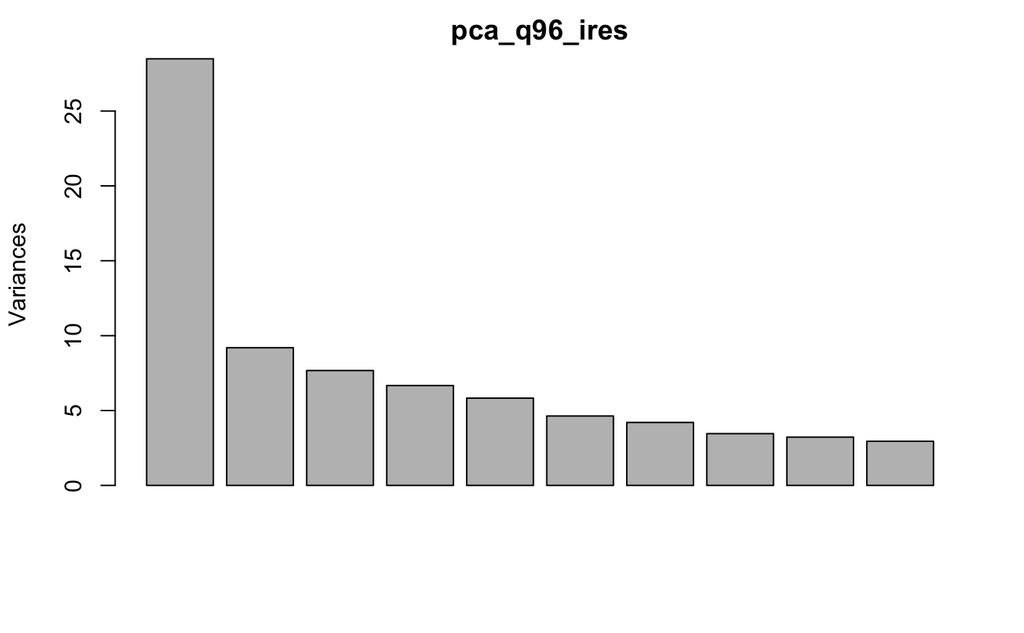

```r
screeplot(pca_q96_ires)
```

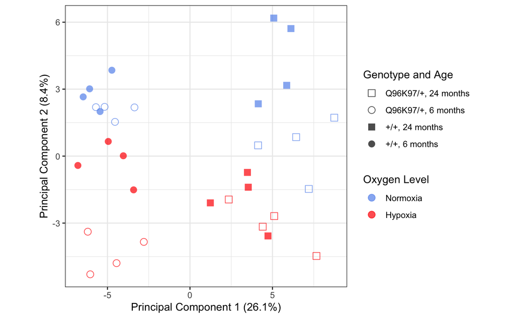

```r
pca_q96_ires_plot
```

```r
# export::graph2ppt(pca_q96_ires_plot, here("R","DE","fig","pca_3utr_ire_geneExpression"))
```

- PCA on Q96K97 data, restricted to **5’ IRE genes** doesn’t show as clear separation, although the samples still do separate by age and possibly oxygen level. However, expression of 5’ IRE genes doesn’t seem to separate samples based on genotype as much as with **3’ IRE genes**.

```r
q96_expressedIREs2 <- q96_dge %>% cpm(log=TRUE) %>%
  as.data.frame %>%
  rownames_to_column("ensembl_gene_id") %>%
  dplyr::filter(ensembl_gene_id %in% ireGenes$ire5_all) %>%
  column_to_rownames("ensembl_gene_id") %>%
  as.matrix
pca_q96_ires2 <- q96_expressedIREs2 %>% t %>% prcomp
pca_q96_ires_plot2 <- pca_q96_ires2$x %>% magrittr::extract(, c("PC1", "PC2")) %>%
  as.data.frame %>%
  rownames_to_column("samples") %>%
  left_join((q96_dge$samples %>% rownames_to_column("samples")), by="samples") %>%
  ggplot(aes(x=PC1, y = PC2, colour = Hypoxia, shape = paste0(Genotype, "_", Age))) +
  geom_point(alpha = 0.7,size=3) +
  scale_shape_manual(values = c(0,1,15,16),
                     labels = c("Q96K97/+, 24 months", "Q96K97/+, 6 months", "+/+, 24 months", "+/+, 6 months")) +
  theme(aspect.ratio = 1) +
  scale_colour_manual(values = c("cornflowerblue", "red"), labels = c("Normoxia", "Hypoxia")) +
    labs(x = "Principal Component 1 (31.67%)", y = "Principal Component 2 (11.35%)",
         colour = "Oxygen Level", shape = "Genotype and Age")
summary(pca_q96_ires2)
```

```
Importance of components:
                          PC1    PC2     PC3    PC4     PC5     PC6     PC7     PC8     PC9    PC10    PC11    PC12
Standard deviation     3.8194 2.2866 1.87211 1.5902 1.43133 1.31347 1.28781 1.25444 1.20664 1.11785 1.04566 0.98777
Proportion of Variance 0.3167 0.1135 0.07609 0.0549 0.04448 0.03746 0.03601 0.03417 0.03161 0.02713 0.02374 0.02118
Cumulative Proportion  0.3167 0.4302 0.50632 0.5612 0.60571 0.64316 0.67917 0.71334 0.74495 0.77208 0.79582 0.81700
                          PC13    PC14    PC15    PC16    PC17    PC18    PC19    PC20   PC21    PC22    PC23    PC24
Standard deviation     0.93690 0.89988 0.85336 0.83977 0.80793 0.76673 0.70407 0.68562 0.6439 0.62040 0.60000 0.58093
Proportion of Variance 0.01906 0.01758 0.01581 0.01531 0.01417 0.01276 0.01076 0.01021 0.0090 0.00836 0.00782 0.00733
Cumulative Proportion  0.83606 0.85364 0.86945 0.88476 0.89893 0.91170 0.92246 0.93267 0.9417 0.95002 0.95784 0.96517
                          PC25    PC26    PC27    PC28    PC29   PC30    PC31      PC32
Standard deviation     0.56248 0.53338 0.47872 0.46865 0.45637 0.4292 0.40266 4.227e-15
Proportion of Variance 0.00687 0.00618 0.00498 0.00477 0.00452 0.0040 0.00352 0.000e+00
Cumulative Proportion  0.97204 0.97821 0.98319 0.98796 0.99248 0.9965 1.00000 1.000e+00
```

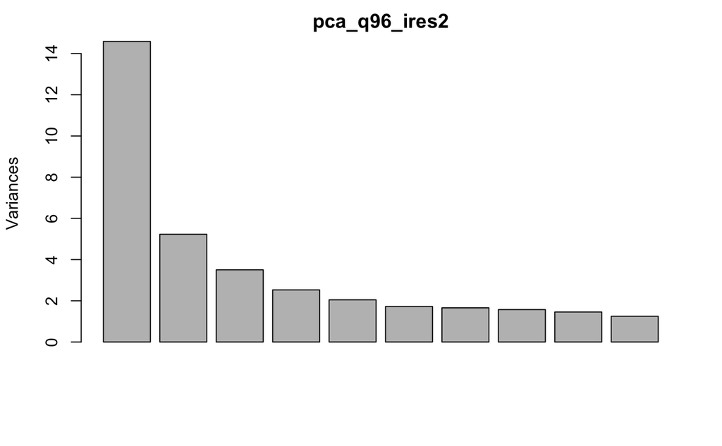

```r
screeplot(pca_q96_ires2)
```

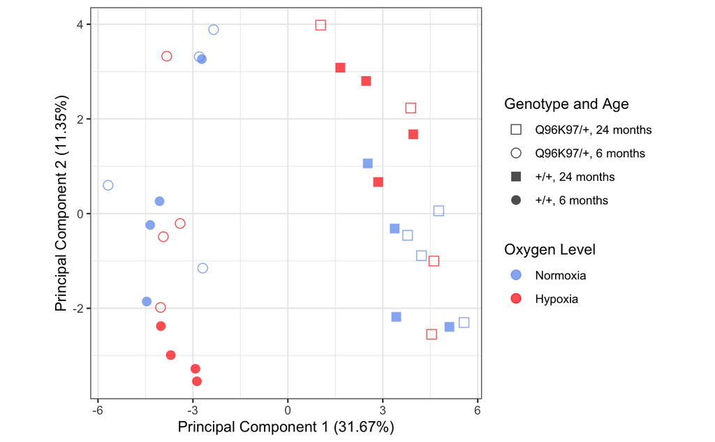

```r
pca_q96_ires_plot2
```

### 3.2. K97fs data

- PCA on K97fs data, restricted to 3’ IRE genes

```r
k97_expressedIREs <- k97_dge %>% cpm(log=TRUE) %>%
  as.data.frame %>%
  rownames_to_column("ensembl_gene_id") %>%
  dplyr::filter(ensembl_gene_id %in% ireGenes$ire3_all) %>%
  column_to_rownames("ensembl_gene_id") %>%
  as.matrix
pca_k97_ires <- k97_expressedIREs %>% t %>% prcomp
pca_k97_ires_plot <- pca_k97_ires$x %>% magrittr::extract(, c("PC1", "PC2")) %>%
  as.data.frame %>%
  rownames_to_column("samples") %>%
  left_join((k97_dge$samples %>% rownames_to_column("samples")), by="samples") %>%
  ggplot(aes(x=PC1, y = PC2, shape = paste0(psen1, "_", months))) +
  geom_point(alpha = 0.7,size=3, colour = "cornflowerblue") +
  scale_shape_manual(values = c(0,1,15,16),
                     labels =c("K97fs/+, 24 months", "K97fs/+, 6 months", "+/+, 24 months", "+/+, 6 months")) +
  theme(aspect.ratio = 1) +
  #scale_colour_manual(values = c("red","cornflowerblue"), labels = c("Hypoxia","Normoxia")) +
    labs(x = "Principal Component 1 (27.65%)", y = "Principal Component 2 (15.06%)",
         shape = "Genotype and Age")
summary(pca_k97_ires)
```

```
Importance of components:
                          PC1    PC2    PC3    PC4     PC5     PC6     PC7     PC8     PC9    PC10    PC11      PC12
Standard deviation     5.8258 4.2997 3.8682 3.6137 3.47610 3.05237 2.53014 2.23444 1.89716 1.84239 1.58149 8.182e-15
Proportion of Variance 0.2765 0.1506 0.1219 0.1064 0.09845 0.07591 0.05216 0.04068 0.02932 0.02766 0.02038 0.000e+00
Cumulative Proportion  0.2765 0.4271 0.5491 0.6554 0.75390 0.82981 0.88196 0.92264 0.95197 0.97962 1.00000 1.000e+00
```

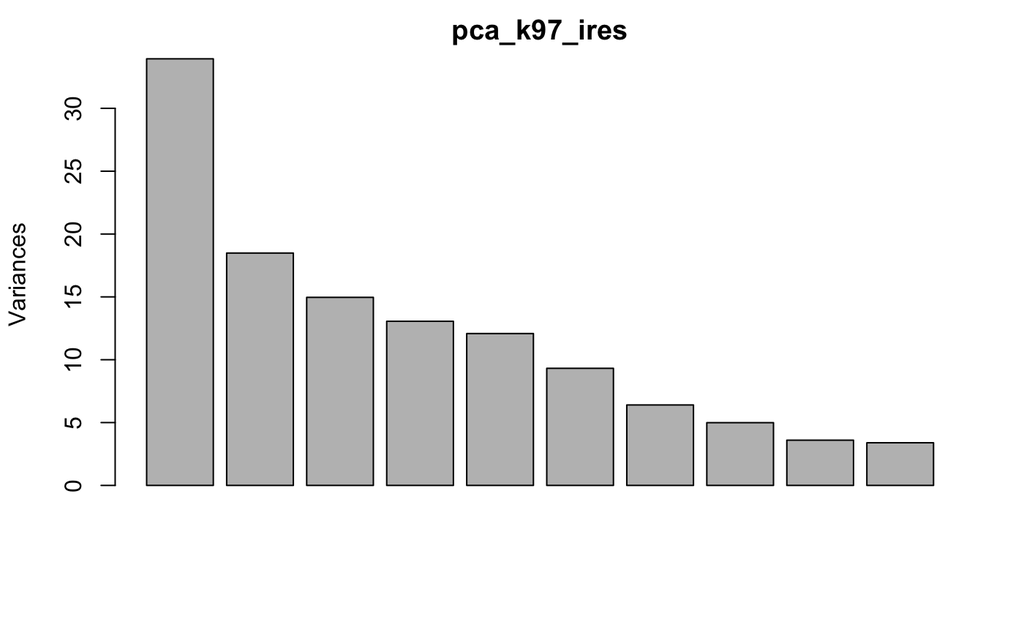

```r
screeplot(pca_k97_ires)
```

```r
pca_k97_ires_plot
export::graph2ppt(pca_k97_ires_plot, here("R/DE/fig/pca_k97_ires_plot"))
```

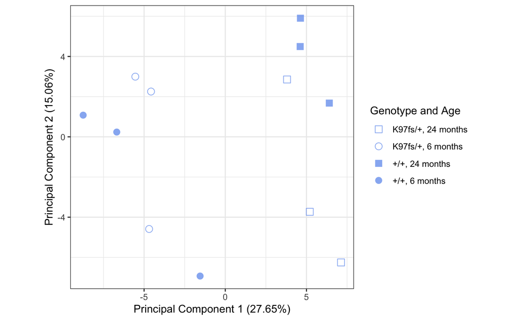

```r
export::graph2pdf(pca_k97_ires_plot, here("R/DE/fig/pca_k97_ires_plot"))
```

- PCA on K97fs data, restricted to 5’ IRE genes

```r
k97_expressedIREs2 <- k97_dge %>% cpm(log=TRUE) %>%
  as.data.frame %>%
  rownames_to_column("ensembl_gene_id") %>%
  dplyr::filter(ensembl_gene_id %in% ireGenes$ire5_all) %>%
  column_to_rownames("ensembl_gene_id") %>%
  as.matrix
pca_k97_ires2 <- k97_expressedIREs2 %>% t %>% prcomp
pca_k97_ires_plot2 <- pca_k97_ires2$x %>% magrittr::extract(, c("PC1", "PC2")) %>%
  as.data.frame %>%
  rownames_to_column("samples") %>%
  left_join((k97_dge$samples %>% rownames_to_column("samples")), by="samples") %>%
  ggplot(aes(x=PC1, y = PC2, shape = paste0(psen1, "_", months))) +
  geom_point(alpha = 0.7,size=3, colour = "cornflowerblue") +
  scale_shape_manual(values = c(0,1,15,16),
                     labels =c("K97fs/+, 24 months", "K97fs/+, 6 months", "+/+, 24 months", "+/+, 6 months")) +
  theme(aspect.ratio = 1) +
  #scale_colour_manual(values = c("red","cornflowerblue"), labels = c("Hypoxia","Normoxia")) +
    labs(x = "Principal Component 1 (26.17%)", y = "Principal Component 2 (22.03%)",
         shape = "Genotype and Age")
summary(pca_k97_ires2)
```

```
Importance of components:
                          PC1    PC2    PC3     PC4     PC5     PC6     PC7     PC8     PC9    PC10    PC11      PC12
Standard deviation     3.6893 3.3848 2.7487 2.19252 2.09664 1.77723 1.59354 1.20281 1.07887 0.99166 0.94801 4.569e-15
Proportion of Variance 0.2617 0.2203 0.1452 0.09242 0.08451 0.06072 0.04882 0.02781 0.02238 0.01891 0.01728 0.000e+00
Cumulative Proportion  0.2617 0.4819 0.6272 0.71958 0.80409 0.86481 0.91363 0.94144 0.96382 0.98272 1.00000 1.000e+00
```

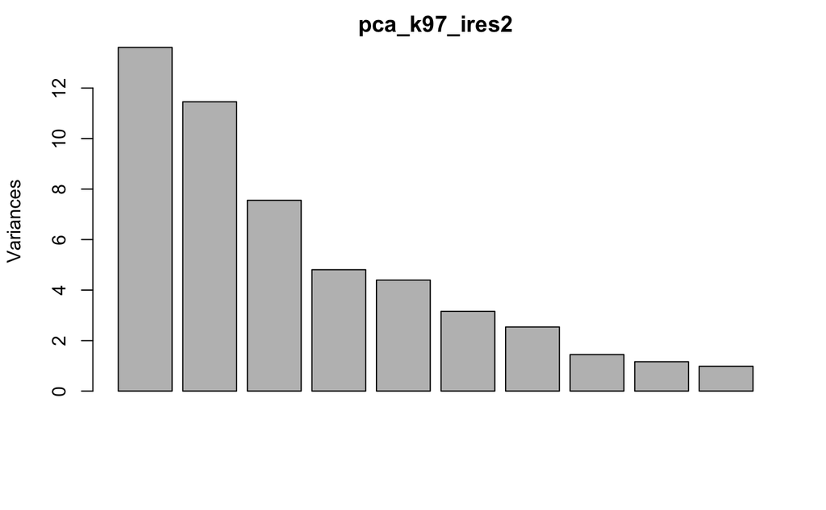

```r
screeplot(pca_k97_ires2)
```

```r
pca_k97_ires_plot2
export::graph2ppt(pca_k97_ires_plot2, here("R/DE/fig/pca_k97_ires_plot2"))
```

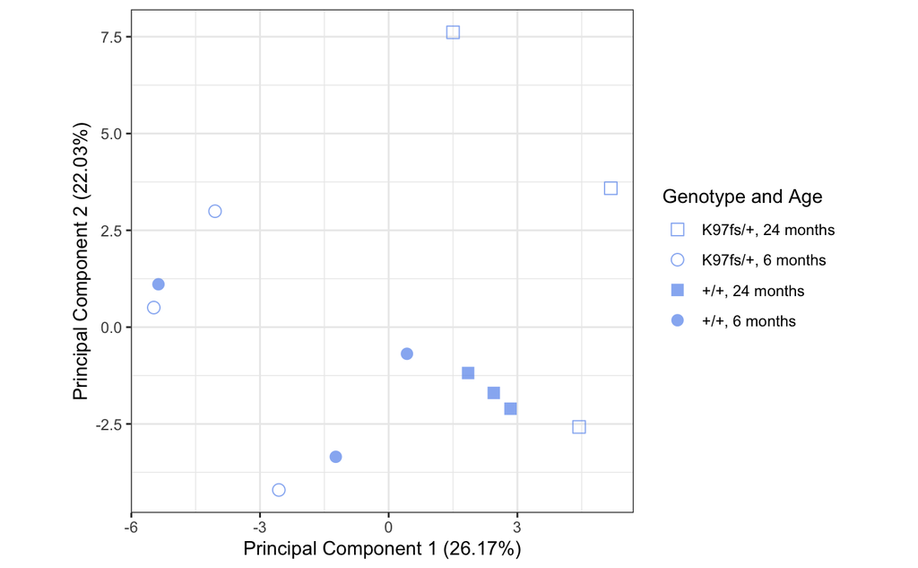

```r
export::graph2pdf(pca_k97_ires_plot2, here("R/DE/fig/pca_k97_ires_plot2"))
```

## 4. t-statistic PCA

- Here we create a PCA of t-statistics from the *limma-voom* DE gene analysis to compare the similarity/differences between DE gene patterns in different comparisons.

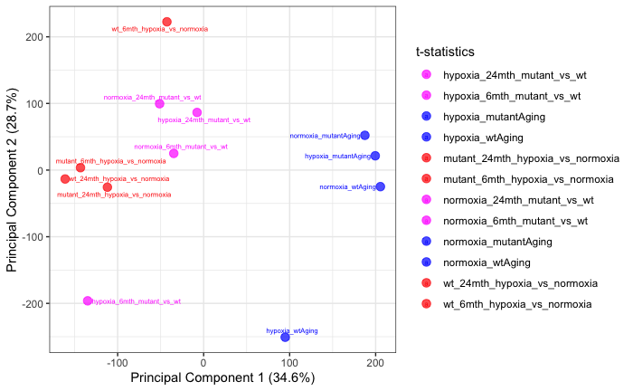